# Association rules I

```r
# install.packages("arules")
library(arules)
```

## Transactions object

We begin with reading our transactions stored in the text file and create transactions.

```r
d.tr<-read.transactions(file = "Data/data.csv", format = "single",
  sep = ",", header = T,
  cols = c("order_id", "product_id"),
  rm.duplicates = FALSE,
  quote = "", skip = 0,
  encoding = "unknown")
d.tr@itemInfo
```

| labels |
| --- |
| \\Louis Ba-Kahn\\ Chocolate Chip Cookie & Brown Butter Candied Bacon Ice Cream Sandwich |
| \\Mokaccino\\ Milk + Blue Bottle Coffee Chocolate |
| #2 Coffee Filters |
| 0% Fat Black Cherry Greek Yogurt y |
| 0% Fat Blueberry Greek Yogurt |
| 0% Fat Free Organic Milk |
| 0% Fat Greek Yogurt Black Cherry on the Bottom |
| 0% Fat Organic Greek Vanilla Yogurt |
| 0% Fat Peach Greek Yogurt |
| 0% Fat Strawberry Greek Yogurt |

[output cut: 990 more lines]

```r
d.tr@data
```

[output not shown]

Let’s look at the parameters of `read.transactions()`, the function used to create the transactions object.

For the first parameter, `file`, we pass our text file where we have the transactions from the retailer. The second parameter, `format`, can take any of two values, single or basket, depending on how the input data is organized. In our case, we have a tabular format with two columns–one column representing the unique identifier for our transaction and the other column for a unique identifier representing the product present in our transaction. This format is named single by arules. Refer to the arules documentation for a detailed description of all the parameters.

## The most frequent items

The function `itemFrequency()` in the arules package takes a transaction object as input and produces the frequency count (the number of transactions containing this product) of the individual products:

## Item frequency

```r
itemFrequency(d.tr, type = "absolute")
```

[output not shown]

[output cut: 1946 more lines]

[output not shown]

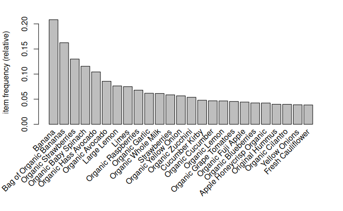

```r
df1=as.data.frame(sort(itemFrequency(d.tr, type = "absolute"), decreasing = TRUE), 10) # Most frequent
df2=as.data.frame(sort(itemFrequency(d.tr, type = "absolute"), decreasing = FALSE), 10) # Least frequent
itemFrequencyPlot(d.tr,topN = 25)
```

## Frequent itemsets

The apriori algorithm works in two phases. Finding the frequent itemsets is the first phase of the association rule mining algorithm. So we can also get the most common sets of our items.

```r
support <- 0.01
```

## Frequent item sets

```r
parameters = list(
 support = support,
 minlen = 2, # Minimal number of items per item set
 maxlen = 10, # Maximal number of items per item set
 target = "frequent itemsets"
)

freq.items <- apriori(d.tr, parameter = parameters)
```

```
Apriori

Parameter specification:
```

|  | confidence | minval | smax | arem | aval | originalSupport | maxtime | support | minlen | maxlen | target | ext |
| --- | --- | --- | --- | --- | --- | --- | --- | --- | --- | --- | --- | --- |
|  | NA | 0.1 | 1 | none | FALSE | TRUE | 5 | 0.01 | 2 | 10 | frequent itemsets | TRUE |

```
Algorithmic control:
```

|  | filter | tree | heap | memopt | load | sort | verbose |
| --- | --- | --- | --- | --- | --- | --- | --- |
|  | 0.1 | TRUE | TRUE | FALSE | TRUE | 2 | TRUE |

```
Absolute minimum support count: 69

set item appearances ...[0 item(s)] done [0.00s].
set transactions ...[16793 item(s), 6988 transaction(s)] done [0.09s].
sorting and recoding items ... [194 item(s)] done [0.00s].
creating transaction tree ... done [0.00s].
checking subsets of size 1 2 3 done [0.00s].
sorting transactions ... done [0.00s].
writing ... [83 set(s)] done [0.00s].
creating S4 object  ... done [0.00s].
```

```r
freq.items.df <- data.frame(item_set = labels(freq.items), support = freq.items@quality)
```

## Association rules

```r
rules.2 <- apriori(d.tr, parameter = list(supp = 0.001, conf = 0.8, maxlen=3))
```

```
Apriori

Parameter specification:
```

|  | confidence | minval | smax | arem | aval | originalSupport | maxtime | support | minlen | maxlen | target | ext |
| --- | --- | --- | --- | --- | --- | --- | --- | --- | --- | --- | --- | --- |
|  | 0.8 | 0.1 | 1 | none | FALSE | TRUE | 5 | 0.001 | 1 | 3 | rules | TRUE |

```
Algorithmic control:
```

|  | filter | tree | heap | memopt | load | sort | verbose |
| --- | --- | --- | --- | --- | --- | --- | --- |
|  | 0.1 | TRUE | TRUE | FALSE | TRUE | 2 | TRUE |

```
Absolute minimum support count: 6

set item appearances ...[0 item(s)] done [0.00s].
set transactions ...[16793 item(s), 6988 transaction(s)] done [0.08s].
sorting and recoding items ... [3103 item(s)] done [0.01s].
creating transaction tree ... done [0.00s].
checking subsets of size 1 2 3
```

```
 done [0.06s].
writing ... [37 rule(s)] done [0.02s].
creating S4 object  ... done [0.00s].
```

```r
summary(rules.2)
```

```
set of 37 rules

rule length distribution (lhs + rhs):sizes
 2  3
 3 34

   Min. 1st Qu.  Median    Mean 3rd Qu.    Max.
  2.000   3.000   3.000   2.919   3.000   3.000

summary of quality measures:
    support           confidence        coverage             lift             count
 Min.   :0.001002   Min.   :0.8000   Min.   :0.001002   Min.   :  3.840   Min.   : 7.000
 1st Qu.:0.001002   1st Qu.:0.8000   1st Qu.:0.001145   1st Qu.:  4.926   1st Qu.: 7.000
 Median :0.001145   Median :0.8750   Median :0.001288   Median :  8.387   Median : 8.000
 Mean   :0.001211   Mean   :0.8580   Mean   :0.001419   Mean   : 51.782   Mean   : 8.459
 3rd Qu.:0.001145   3rd Qu.:0.8824   3rd Qu.:0.001431   3rd Qu.: 24.168   3rd Qu.: 8.000
 Max.   :0.002290   Max.   :1.0000   Max.   :0.002719   Max.   :679.389   Max.   :16.000

mining info:
```

|  | data | ntransactions | support | confidence | call |
| --- | --- | --- | --- | --- | --- |
|  | d.tr | 6988 | 0.001 | 0.8 | apriori(data = d.tr, parameter = list(supp = 0.001, conf = 0.8, maxlen = 3)) |

```r
rules.2.sort <- sort (rules.2 , by="support", decreasing=TRUE)
inspect(rules.2.sort)
```

```
     lhs                                                              rhs                                                                    support confidence    coverage       lift count
[1]  {Lime Sparkling Water,
      Sparkling Water Berry}                                       => {Sparkling Water Grapefruit}                                       0.002289639  0.8421053 0.002718947  24.316659    16
[2]  {Lime Sparkling Water,
      Peach Pear Flavored Sparkling Water}                         => {Sparkling Water Grapefruit}                                       0.002289639  0.8421053 0.002718947  24.316659    16
[3]  {Non Fat Raspberry Yogurt,
      Nonfat Icelandic Style Strawberry Yogurt}                    => {Icelandic Style Skyr Blueberry Non-fat Yogurt}                    0.002146537  0.8823529 0.002432742  81.130031    15
[4]  {Peach Pear Flavored Sparkling Water,
      Sparkling Lemon Water}                                       => {Sparkling Water Grapefruit}                                       0.001717230  0.8000000 0.002146537  23.100826    12
[5]  {Non Fat Acai & Mixed Berries Yogurt,
      Nonfat Icelandic Style Strawberry Yogurt}                    => {Non Fat Raspberry Yogurt}                                         0.001287922  0.9000000 0.001431025  95.290909     9
[6]  {Non Fat Acai & Mixed Berries Yogurt,
      Nonfat Icelandic Style Strawberry Yogurt}                    => {Icelandic Style Skyr Blueberry Non-fat Yogurt}                    0.001287922  0.9000000 0.001431025  82.752632     9
[7]  {Organic Mint,
      Organic Red Onion}                                           => {Organic Cilantro}                                                 0.001287922  0.8181818 0.001574127  20.566383     9
[8]  {Garlic,
      Organic Whole Milk}                                          => {Banana}                                                           0.001287922  0.8181818 0.001574127   3.926823     9
[9]  {Mighty 4 Kale Strawberry Amaranth & Greek Yogurt Tots Snack} => {Mighty 4 Sweet Potato Blueberry Millet & Greek Yogurt Tots Snack} 0.001144820  0.8000000 0.001431025 372.693333     8
[10] {2% Reduced Fat Milk,
      Fresh CA Grown Eggs}                                         => {Banana}                                                           0.001144820  0.8888889 0.001287922   4.266178     8
[11] {Bag of Organic Bananas,
      Bing Cherries}                                               => {Organic Strawberries}                                             0.001144820  0.8000000 0.001431025   6.156828     8
[12] {Peach Pear Flavored Sparkling Water,
      Pure Sparkling Water}                                        => {Sparkling Water Grapefruit}                                       0.001144820  0.8000000 0.001431025  23.100826     8
[13] {Organic Cilantro,
      Organic Shredded Carrots}                                    => {Limes}                                                            0.001144820  0.8000000 0.001431025  10.668702     8
[14] {Organic Red Cabbage,
      Organic Small Bunch Celery}                                  => {Organic Cucumber}                                                 0.001144820  0.8000000 0.001431025  17.096024     8
[15] {Icelandic Style Skyr Blueberry Non-fat Yogurt,
      Organic Fuji Apple}                                          => {Banana}                                                           0.001144820  0.8888889 0.001287922   4.266178     8
[16] {Organic Fuji Apple,
      Total 0% Nonfat Greek Yogurt}                                => {Banana}                                                           0.001144820  0.8888889 0.001287922   4.266178     8
[17] {Organic Romaine,
      Seedless Red Grapes}                                         => {Organic Strawberries}                                             0.001144820  0.8888889 0.001287922   6.840920     8
[18] {Grape White/Green Seedless,
      Organic Grape Tomatoes}                                      => {Banana}                                                           0.001144820  0.8000000 0.001431025   3.839560     8
[19] {Organic Large Extra Fancy Fuji Apple,
      Uncured Genoa Salami}                                        => {Bag of Organic Bananas}                                           0.001144820  0.8888889 0.001287922   5.472736     8
[20] {Bunched Cilantro,
      Organic Fuji Apple}                                          => {Banana}                                                           0.001144820  0.8000000 0.001431025   3.839560     8
```

[output cut: 17 more lines]

```
      Organic Strawberries}                                        => {Bag of Organic Bananas}                                           0.001001717  0.8750000 0.001144820   5.387225     7
[31] {Organic Small Bunch Celery,
      Organic Tomato Paste}                                        => {Carrots}                                                          0.001001717  0.8750000 0.001144820  24.167984     7
[32] {Cantaloupe,
      Organic D'Anjou Pears}                                       => {Bag of Organic Bananas}                                           0.001001717  0.8750000 0.001144820   5.387225     7
[33] {Large Lemon,
      Non Fat Raspberry Yogurt}                                    => {Icelandic Style Skyr Blueberry Non-fat Yogurt}                    0.001001717  0.8750000 0.001144820  80.453947     7
[34] {Organic Large Extra Fancy Fuji Apple,
      Organic Whole Strawberries}                                  => {Organic Hass Avocado}                                             0.001001717  0.8750000 0.001144820   8.387517     7
[35] {Organic Italian Parsley Bunch,
      Organic Roasted Turkey Breast}                               => {Bag of Organic Bananas}                                           0.001001717  0.8750000 0.001144820   5.387225     7
[36] {Carrots,
      Large Alfresco Eggs}                                         => {Organic Yellow Onion}                                             0.001001717  0.8750000 0.001144820  15.440657     7
[37] {Organic Small Bunch Celery,
      Unsweetened Almondmilk}                                      => {Bag of Organic Bananas}                                           0.001001717  0.8750000 0.001144820   5.387225     7
```

```r
inspect(rules.2.sort[1:5])
```

```
    lhs                                           rhs                                                 support confidence    coverage     lift count
[1] {Lime Sparkling Water,
     Sparkling Water Berry}                    => {Sparkling Water Grapefruit}                    0.002289639  0.8421053 0.002718947 24.31666    16
[2] {Lime Sparkling Water,
     Peach Pear Flavored Sparkling Water}      => {Sparkling Water Grapefruit}                    0.002289639  0.8421053 0.002718947 24.31666    16
[3] {Non Fat Raspberry Yogurt,
     Nonfat Icelandic Style Strawberry Yogurt} => {Icelandic Style Skyr Blueberry Non-fat Yogurt} 0.002146537  0.8823529 0.002432742 81.13003    15
[4] {Peach Pear Flavored Sparkling Water,
     Sparkling Lemon Water}                    => {Sparkling Water Grapefruit}                    0.001717230  0.8000000 0.002146537 23.10083    12
[5] {Non Fat Acai & Mixed Berries Yogurt,
     Nonfat Icelandic Style Strawberry Yogurt} => {Non Fat Raspberry Yogurt}                      0.001287922  0.9000000 0.001431025 95.29091     9
```

```r
write(rules.2.sort, file = "reguly_1.csv", quote=TRUE, sep = ",", col.names = NA)
```

## To exclude certain items

Let us notice, that our itemsets consist mostly of the high frequency itemsets. However, we can ask the apriori method to ignore some of the items:

```r
exclusion.items <- c('Banana','Bag of Organic Bananas')
```

## For the frequent items

```r
freq.items2 <- apriori(d.tr, parameter = parameters,
 appearance = list(none = exclusion.items,
 default = "both"))
```

```
Apriori

Parameter specification:
```

|  | confidence | minval | smax | arem | aval | originalSupport | maxtime | support | minlen | maxlen | target | ext |
| --- | --- | --- | --- | --- | --- | --- | --- | --- | --- | --- | --- | --- |
|  | NA | 0.1 | 1 | none | FALSE | TRUE | 5 | 0.01 | 2 | 10 | frequent itemsets | TRUE |

```
Algorithmic control:
```

|  | filter | tree | heap | memopt | load | sort | verbose |
| --- | --- | --- | --- | --- | --- | --- | --- |
|  | 0.1 | TRUE | TRUE | FALSE | TRUE | 2 | TRUE |

```
Absolute minimum support count: 69

set item appearances ...[2 item(s)] done [0.00s].
set transactions ...[16793 item(s), 6988 transaction(s)] done [0.08s].
sorting and recoding items ... [192 item(s)] done [0.01s].
creating transaction tree ... done [0.00s].
checking subsets of size 1 2 3 done [0.00s].
sorting transactions ... done [0.00s].
writing ... [40 set(s)] done [0.00s].
creating S4 object  ... done [0.01s].
```

```r
freq.items.df2 <- data.frame(item_set = labels(freq.items2)
 , support = freq.items2@quality)
```

## For the rules

```r
rules.3 <- apriori(d.tr, parameter = list(supp = 0.001, conf = 0.8),
 appearance = list(none = exclusion.items))
```

```
Apriori

Parameter specification:
```

|  | confidence | minval | smax | arem | aval | originalSupport | maxtime | support | minlen | maxlen | target | ext |
| --- | --- | --- | --- | --- | --- | --- | --- | --- | --- | --- | --- | --- |
|  | 0.8 | 0.1 | 1 | none | FALSE | TRUE | 5 | 0.001 | 1 | 10 | rules | TRUE |

```
Algorithmic control:
```

|  | filter | tree | heap | memopt | load | sort | verbose |
| --- | --- | --- | --- | --- | --- | --- | --- |
|  | 0.1 | TRUE | TRUE | FALSE | TRUE | 2 | TRUE |

```
Absolute minimum support count: 6

set item appearances ...[2 item(s)] done [0.00s].
set transactions ...[16793 item(s), 6988 transaction(s)] done [0.07s].
sorting and recoding items ... [3101 item(s)] done [0.00s].
creating transaction tree ... done [0.00s].
checking subsets of size 1 2 3 4 done [0.07s].
writing ... [31 rule(s)] done [0.02s].
creating S4 object  ... done [0.00s].
```

```r
rules.3.sort <- sort (rules.3 , by="support", decreasing=TRUE)
inspect(rules.3.sort[1:5])
```

```
    lhs                                           rhs                                                 support confidence    coverage     lift count
[1] {Lime Sparkling Water,
     Sparkling Water Berry}                    => {Sparkling Water Grapefruit}                    0.002289639  0.8421053 0.002718947 24.31666    16
[2] {Lime Sparkling Water,
     Peach Pear Flavored Sparkling Water}      => {Sparkling Water Grapefruit}                    0.002289639  0.8421053 0.002718947 24.31666    16
[3] {Non Fat Raspberry Yogurt,
     Nonfat Icelandic Style Strawberry Yogurt} => {Icelandic Style Skyr Blueberry Non-fat Yogurt} 0.002146537  0.8823529 0.002432742 81.13003    15
[4] {Peach Pear Flavored Sparkling Water,
     Sparkling Lemon Water}                    => {Sparkling Water Grapefruit}                    0.001717230  0.8000000 0.002146537 23.10083    12
[5] {Lime Sparkling Water,
     Peach Pear Flavored Sparkling Water,
     Sparkling Lemon Water}                    => {Sparkling Water Grapefruit}                    0.001431025  0.9090909 0.001574127 26.25094    10
```

We can create a vector of items to be excluded, and pass it as an appearance parameter to the apriori method. This will ensure that the items in our list are excluded from the generated itemsets.